# Tópicos en Economía Política Moderna

Unidad 2. ¿La democracia es el peor sistema de gobierno? Si, con excepción de todas las demás

Sebastian Freille

Universidad Nacional de Córdoba

> El poder no es un medio, sino un fin en si mismo. No se establece una dictadura para salvaguardar una revolución; se hace la revolución para establecer una dictadura  
> **[George Orwell, *1984* (1949)]**

# **Democracia en el mundo**

- Hechos estilizados
- Indices de democracia y democratización
- Democracia y desarrollo económico

## La democracia no es una constante

- No siempre ni en todo momento y lugar hubo democracia.
  - En 1800, sólo 4% eran democracias
  - En 1900, 22% de países eran democracias
  - En 2020, más del 60% son democracias
- El fin de la 1GM recuperó muchas democracias pero fueron de corta duración –entre 1920 y 1940, muchas reviertieron al autoritarismo
- Episodios de desestabilización democrática frecuentes en últimas décadas –no sólo en LATAM, Asia y Africa sino en América del Norte y Europa
  - *Democratic backsliding*

## La democracia se ha expandido…

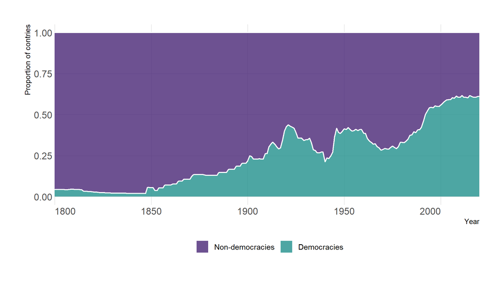

El ascenso de la democracia en los últimos 200 años

## …pero no tan rápido ni sostenido

[figure not shown]

La “edad” de las democracias electorales

## ¿Cómo mueren las democracias?

- Dos formas en que las democracias mueren
  - A manos de *hombres con armas*
    - Argentina, Brasil, Ghana, Grecia, Guatemala, Nigeria, Pakistan, Tailandia, Turquía y Uruguay durante guerra fría
    - Egipto y Tailandia en 2013/2014
  - A manos de *líderes electos*
    - Hitler en Alemania, Chávez en Venezuela
    - Pero también en Hungría, Nicaragua, Perú, Filipinas, Polonia, Rusia, y Turquia.

## ¿Cómo mueren las democracias? (cont.)

[figure not shown]

Inglés

[figure not shown]

Español

Figura 1: Cómo mueren las democracias

## Clasificación de las democracias

- Desafiante comparar y clasificar diferentes países. Esfuerzos como V-Dem (https://www.v-dem.net/):
  1. **Autocracias cerradas** $\longrightarrow$ sin derecho a elegir ni al ejecutivo ni al legislativo
  2. **Autocracias electorales** $\longrightarrow$ con derecho a elegir ejecutivo y legislativo via elecciones pero carecen de varias libertades
  3. **Democracias electorales** $\longrightarrow$ ciudadanos tienen derecho a aparticipar en elecciones relevantes, libres, justas y multipartido
  4. **Democracias liberales** $\longrightarrow$ indiviuos y minorías tienen derechos adicionales, son iguales ante la ley, y el PE está restringido por PL y PJ

## Indicadores y fuentes

- Hay varias fuentes de datos relevantes:
  1. Varieties of Democracy (V-Dem): [V-Dem](https://www.v-dem.net/vdemds.html)
  2. Regimes of the World (RoW)
  3. Lexical Index of Electoral Democracy (LIE): https://dataverse.harvard.edu/dataset.xhtml?persistentId=doi:10.7910/DVN/WPKNIT
  4. Polity: https://www.systemicpeace.org/inscrdata.html
  5. Freedom House: https://freedomhouse.org/report/freedom-world
  6. EIU: https://www.eiu.com/n/campaigns/democracy-index-2021/?utm_source=eiu-website&utm_medium=blog&utm_campaign=democracy-index-2021

## Indicadores y fuentes (cont.)

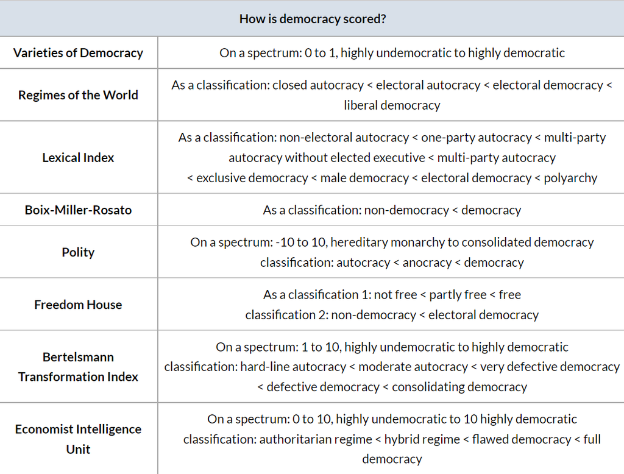

Indices y cobertura

## Democratización

- Teoría tradicional de ciencia política argumenta que educación es un determinante clave de la emergencia y sostenibilidad democrática
  - Educación promueve y alienta participación política y dedsarrolla un settido colectivo de deber cívico
- Deberíamos esperar una correlación entre educación en el pasado y condiciones democráticas hoy
- También hay evidencias sobre la relación entre:
  - Democracia y PIB per capita
  - Democracia y resultados sanitarios

## Democratización (cont.)

[figure not shown]

Grado de democracia liberal (hoy) y educación (hace 50 años)

## Democratización (cont.)

[figure not shown]

Democracia y PIB per capita

## Democratización (cont.)

[figure not shown]

Democracia y resultados sanitarios

# **Transiciones democráticas**

- Actores y decisiones en no-democracia
- Redistribución y revolución
- El problema de la credibilidad

## Contextualización

- En las primeras democracias el voto no era universal ni extendido –primeros ciudadanos con derecho al voto fueron ricos. ¿Por qué se extendió el derecho al voto?
  - Elite debería oponorse –i.e recuerde TVM
- Acemoglu and Robinson (2000,2006) $\longrightarrow$ democratización es una respuesta de élites a la amenaza de revolución por parte de los pobres
  - Hay tres tipos de modelos
    1. No democracia
    2. Democratización
    3. Democratización y represión

## Democracia versus no-democracia

- Distinción más básica y esencial $\longrightarrow$ las democracias constituyen situaciones de igualdad de derechos políticos –un ciudadano, un voto
  - todas las preferencias importan
- En no-democracia, sólo importan las preferencias de un sub-conjunto de la población, una *elite*
  - Dos factores moldean las políticas públicas en una no-democracia
    1. Las preferencias del grupo en poder
    2. Las restricciones enfrentadas por el grupo en el poder

## Democracia versus no-democracia (cont.)

- Un punto central y relevante en las no-democracias es que la política pública tiene un límite
  - asegurar que *ningún grupo está lo suficientemente fastidiado* como para intentar deponer al grupo en el poder
- Una posibilidad es que la *democratización* sea una respuesta de las elites a la amenaza de revolución de los pobres
  - aquí entra la distinción entre *poder político de iure* y *poder político de facto*
- En un sociedad oligárquica, ricos tienen todo el *poder de iure* pero tanto ricos como pobres tienen *poder de facto*

## Democracia versus no-democracia (cont.)

- *Poder de iure* es más permanente y duradero que el *poder de facto* que es solo temporario
  - por eso pobres tienden a usar el (transitorio) *poder de facto* como amenaza de revolución para obligar a los ricos que le transfieran *poder de iure* y así a través de este lograr una mayor redistribución a futuro
- Es importante primero entender las interacciones económicas y políticas entre ricos y pobres en no-democracias
  - es útil utilizar el marco analítico de Meltzer and Richard (1981) como punto de partida

## Democracia versus no-democracia (cont.)

- Se usa un juego no-cooperativo para modelar las interacciones. La naturaleza determina si el *poder de facto* de los pobres es alto, $H$, o bajo, $L$. Esto determina absolutamente la credibilidad de la amaneza de revolución, $R$ –note la aleatoriedad del *poder de facto*
- Una vez que juega la naturaleza, los ricos deciden la política redistributiva, $\hat{\tau}$
  - Observada esta, pobres deciden sobre si hacer $R$ o $NR$
- Si los pobres hacen $R$, siempre es exitosa –IMPORTANTE: ¿por qué?

## Democracia versus no-democracia (cont.)

- Las revoluciones son costosas para la sociedad y destruyen una fracción, $\mu^{S}$$ del ingreso. El pago luego de una revolución es:

$$\begin{align}
V^{p}(R,\mu^{S})&=\frac{(1-\mu^{S})y}{1-\delta} \\
V^{r}(R,\mu^{H})&=V^{r}(R,\mu^{L})=0
\end{align}$$

- Como puede verse, el pago de los ricos no depende del estado de la naturaleza. Si se hace $R$, terminan con cero
- Pero cuando el *poder de facto* es $L$ la destrucción es tan grande que tanto pobres como ricos terminan con cero –ie $\mu^{L}=1$.

## Modelo simple de no democracia

- Sociedad formada por 2 (dos) grupos: pobres con proporción $1-\delta$ y ricos $\delta$. Supuesto: $\delta<\frac{1}{2}$.
- Parámetro $\theta$ captura desigualdad –proporción de ingreso total de los ricos. Ingreso son:
  $$\begin{align}
  y^{p}=\frac{(1-\theta)y}{1-\delta} \qquad y^{r}=\frac{\theta y}{\delta}
  \end{align}$$

## Modelo simple de no democracia (cont.)

- Supuesto: $\theta>\delta$. Todos pagan $\tau$, reciben $T$ netas de DWL $c(\tau)$ tal que $c''()>0$. La U individual:
  $$\begin{align}
  V(y^{i}|\tau)=(1-\tau)y^{i}+(\tau-c(\tau))y
  \end{align}$$
- Equilibrio: $\tau^{r}=0$ y $\tau^{p}$ es creciente en el nivel de desigualdad

## Toma de decisiones

- Naturaleza determina si *poder de facto* de pobres es H (amenaza creíble)o L (amenaza no creíble). Luego, ricos eligen la política redistributiva: $\hat{\tau}$. Pobres deciden si hacer revolución (R) o no (NR)
- Revolución siempre es exitosa (supuesto) y se termina el juego pero se destruye una fracción $\mu^{S}$ [para $S=L,H$] del ingreso total. El ingreso de los pobres luego de R es:
  $$\begin{align}
  V^{p}(R,\mu^{S})&=\frac{(1-\mu^{S})y}{1-\delta} \\
  V^{r}(R,\mu^{H})&=V^{r}(R,\mu^{L})=0
  \end{align}$$
- y no depende del estado de la naturaleza

## Arbol de decisiones y pagos

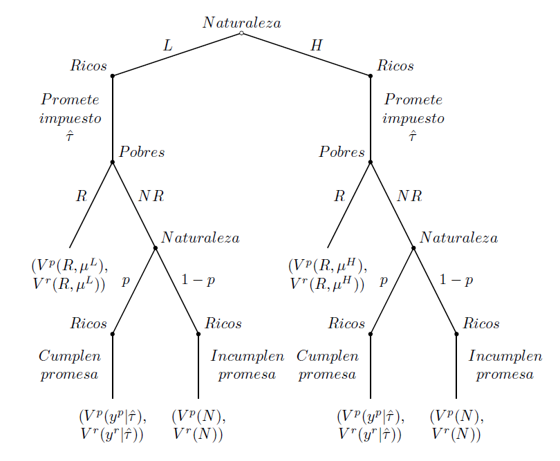

Decisiones y *payoffs* en no democracia

## Resolución del juego

- Supuesto $\longrightarrow$ $\mu^{L}=1$ y $\mu^{H}=\mu \in (0,1)$
  - Si $\mu^{S}=\mu^{L}=1$ destrucción total e ingresos igual a 0
  - Pobres nunca hacen R [¿por qué?]
- Siempre que naturaleza elija $S=L$, amenaza de R de pobres no creíble –ie *poder de facto* bajo
- Si pobres eligen NR, ricos pueden cumplir ($\hat{\tau}$) con prob $p$ o incumplir ($\tau^{r}=0$) con prob $1-p$
  - Intución $\longrightarrow$ *poder de facto* es transitorio y ricos tienen *poder de iure* no pueden comprometerse a cumplir creíblemente

## Resolución del juego (cont.)

- Si ricos:
  - Cumplen $\longrightarrow$ $V^{i}(y|\hat{\tau})=(1-\hat{\tau})y^{i}+(\hat{\tau}-c(\hat{\tau}))y$ para $i \in {p,r}$
  - No cumplen $\longrightarrow$ $V^{p}(N)=y^{p}$ y $V^{r}(N)=y^{r}$
- Inducción para atrás. Pobres deciden si R o NR
  $$\begin{align}
  V^{p}(N,\hat{\tau})&=pV^{p}(y|\hat{\tau})+(1-p)V^{p}(N) \\
  V^{p}(N,\hat{\tau})&=p[(1-\hat{\tau})y^{p}+(\hat{\tau}-c(\hat{\tau}))y]+(1-p)y^{p} \\
  V^{p}(N,\hat{\tau})&=p[y^{p}-\hat{\tau}y^{p}+\hat{\tau}y-c(\hat{\tau})y]+y^{p}-py^{p} \\
  V^{p}(N,\hat{\tau})&=y^{p}+p[\hat{\tau}(y-y^{p})-c(\hat{\tau}y) > 0
  \end{align}$$

## Resolución del juego (cont.)

- Naturaleza elige *poder de facto* bajo $S=L$ p/ pobres. Acá pobres siempre peor con R que con NR $\longrightarrow$ eligen NR
  $$\begin{align}
  V^{p}(N,\hat{\tau})>V^{p}(R,\mu^{L})=0
  \end{align}$$
- Ricos anticipan que pobres nunca eligen R; anuncian su punto ideal $\tau^{N}(\mu^{L})=0$
- Naturaleza elige *poder de facto* alto $S=H$ (pobres). Restricción de revolución:
  $$\begin{align}
  V^{p}(R,\mu^{H})&>V^{p}(N,\tau^{N}=0)=V^{p}(N) \\
  \frac{(1-\mu)y}{1-\delta} &> \frac{(1-\theta)y}{1-\delta} \\
  \theta &> \mu
  \end{align}$$

## Resolución del juego (cont.)

- NOTE: $R$ sólo es atractiva para pobres si lo que expropian a ricos ($\theta$) es mayor a lo que se destruye en el proceso ($\mu$). Entonces ricos eligen su tasa preferida, $\tau^{N}(\mu^{H})=\tau^{r}=0$.
- Si se cumple la condición, pobres prefieren $R$ a $NR$. Ricos prefieren evitar $R$ y permanecer en no democracia $\longrightarrow$ sólo viable si ofrecen redistribución positiva
- ¿Pueden los pobres preferir $R$ aún con redistribución?
  - Si –comparar pago de pobres permaneciendo en no democracia con $\tau^{p}$ versus pago de realizar $R$

## Resolución del juego (cont.)

$$\begin{align}
V^{p}(N,\tau^{N}=\tau^{p}) &\geq V^{p}(R,\mu^{H}) \\
y^{p}+p(\tau^{p}(y-y^{p})-c(\tau^{p})y) &\geq \frac{(1-\mu)y}{1-\delta} \\
\frac{(1-\theta)y}{1-\delta}+p(\tau^{p}(y-\frac{(1-\theta)y}{1-\delta})-c(\tau^{p}y)) &\geq \frac{(1-\mu)y}{1-\delta} \\
(1-\theta)+p\tau^{p}(\theta-\delta)-p(1-\delta)c(\tau^{p}) &\geq (1-\mu) \\
\mu \geq \theta-p(\tau^{p}(\theta-\delta)-(1-\delta)c(\tau^{p})) \equiv \mu^{*}
\end{align}$$

## Resolución del juego (cont.)

- Promesas de redistribución logran evitar $R$ siempre que $R$ sea lo suficientemente costosa
  - Si $\mu < \mu^{*}$ $\longrightarrow$ ni siquera $\tau^{p}$ evita $R$ [hay $R$ en equilibrio]
  - Si $\mu \geq \mu^{*}$ $\longrightarrow$ ricos ofrecen redistribución y se evita $R$. ¿A qué tasa? $\tilde{\tau}$ que hace indiferente a pobres
    $$\begin{align}
    \mu=\theta-p(\tilde{\tau}(\theta-\delta)-(1-\delta)c(\tilde{\tau}))
    \end{align}$$

## Resolución del juego (cont.)

**Proposición 1**

Hay un equilibrio perfecto en subjuegos único para el juego representado en la figura descrito por los siguientes resultados

## Resolución del juego (cont.)

**Proposición 1 (cont.)**

- Si $\theta \leq \mu$ la RdR no se cumple, ricos no ofrecen redistribución ($\tau^{N}(\mu)=0$) y pobres eligen $NR$
- Si $\theta > \mu$:
  1. **Si $\mu<\mu^{*}$**
     - En estado $S=L$ las elites no redistribuyen ($\tau^{N}(\mu^{L})=0$) y pobres hacen $NR$
     - En estado $S=H$, pobres hacen $R$
  2. **Si $\mu \geq \mu^{*}$** pobres deciden $NR$.
     - En estado $S=L$, ricos fijan $\tau^{r}=0$
     - En estado $S=H$ prometen $\tilde{\tau}$

## Resolución del juego (cont.)

- **Costo de revoluciones** $\longrightarrow$ mientras menos $y$ destruya una $R$ ($\mu$ relativamente bajo) más atractiva resultará una revolución
- **Desigualdad** $\longrightarrow$ a mayor desigualdad:
  - más probable que se cumpla RdR
  - más probable que promesas de redistribución sean insuficientes

## Resolución del juego (cont.)

- En este simple modelo, hay situaciones en que los pobres deciden hacer una revolución -para ricos, el peor resultado posible
  - son expropiados
  - terminan con $y=0$
- No siempre promesas de redistribución *creíbles*
- ¿Alguna otra opción?
  - Pasar de no democracia a democracia

## Modelo de democratización

- ¿Qué pasaría si los ricos pudieran ofrecer **democratización** como alternativa? Ahora ricos tienen mas opciones para evitar la revolución
- Si $S=L$ $\longrightarrow$ revolución muy costosa ($\mu^{L}=1$), ricos no redistribuyen ($\tau^{N}(\mu^{L})=0$) y no hay cambio de régimen
- Resultado mas interesante $S=H$:
  - No democracia, redistribuir a ($\hat{\tau}$) pero elegir la política económica
  - Democracia y delegar la elección de política económica a los pobres [¿por qué]
- Los pobres eligen si R o NR una vez que observan el régimen político y el nivel de redistribución

## Modelo de democratización (cont.)

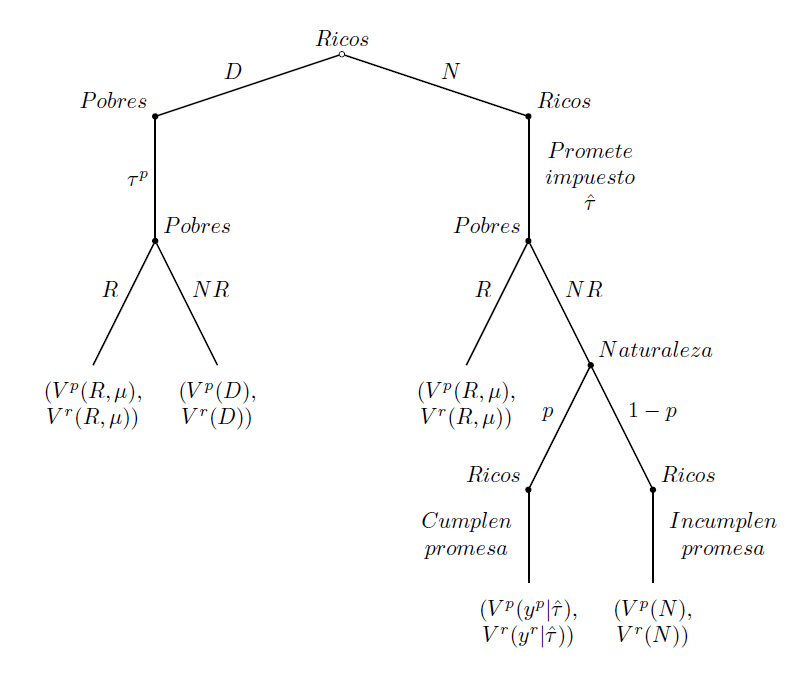

Decisiones y *payoffs* en democratización

## Modelo de democratización (cont.)

- Recordar que decisión de ricos es $D$, $N$.
- **Si pobres eligen $R$** $\longrightarrow$ el juego termina y los pagos son iguales que en no democracia:
  $$\begin{align}
  V^{p}(R,\mu)&=\frac{(1-\mu)y}{1-\delta} \\
  V^{r}(R,\mu)&=0
  \end{align}$$

## Modelo de democratización (cont.)

- **Si pobres eligen $NR$** $\longrightarrow$ pagos dependen del régimen político elegido por ricos inicialmente
  - **Democracia (D)** $\longrightarrow$ fija el mediano ($\tau^{p}$)
    $$\begin{align}
    V^{p}(D)&=y^{p}+[\tau^{p}(y-y^{p})-c(\tau^{p})y] \\
    V^{r}(D)&=y^{r}+[\tau^{p}(y-y^{r})-c(\tau^{p})y]
    \end{align}$$
  - **No-democracia (N)** $\longrightarrow$ ricos deciden política y sólo tienen que cumplir promesa de redistribuir con probabilidad $p$. Pago esperado de pobres:
    $$\begin{align}
    V^{p}(N,\tau^{N})=y^{p}+p[\tau^{N}(y-y^{p})-c(\tau^{N})y]
    \end{align}$$

## Modelo de democratización (cont.)

- Diferencia entre $V^{p}(D)$ y $V^{p}(N)$
  - En $D$ los pobres reciben *transferencia positiva con certeza* a $\tau^{p}$ [ponele…]
  - En $N$ los pobres reciben *transferencia positiva con probabilidad $p$*
    - Dos problemas: a) *commitment*, b) no certeza que $\tau^{N} \neq \tau^{p}$
- Resolución por inducción hacia atras

## Resolución del juego

- Restricción de revolución (amenaza creíble)
  $$\begin{align}
  V^{p}(R,\mu) &> V^{p}(N) = y^{p} \\
  \theta &> \mu
  \end{align}$$
- Siempre que la desigualdad sea mayor a la destrucción causada por $R$, ricos deben: 1) hacer concesiones y prometer redistribución en $N$, 2) democratizar

## Resolución del juego (cont.)

- Ricos siempre prefieren $(N,NR) \succ (D,NR)$. ¿Qué pasa si prometen $\tau^{p}$:
  $$\begin{align}
  V^{p}(N,\tau^{N}=\tau^{p}) &\geq V^{p}(R,\mu^{H}) \\
  \mu \geq \theta-p(\tau^{p}(\theta-\delta)-(1-\delta)c(\tau^{p})) &\equiv \mu^{*}
  \end{align}$$
- Siempre que $\mu < \mu^{*}$ como antes, ricos no pueden evitar $R$ aún redistribuyendo
- La única posibilidad es que puedan evitar $R$ ofreciendo democratización [¿podrán?]

## Resolución del juego (cont.)

$$\begin{align}
V^{p}(D) &\geq V^{p}(R,\mu^{H}) \\
y^{p}+[\tau^{p}(y-y^{p})-c(\tau^{p})y] &\geq \frac{(1-\mu)y}{1\delta} \\
\frac{(1-\theta)y}{1-\delta}+[\tau^{p}(y-\frac{(1-\theta)y}{1-\delta})-c(\tau^{p})y] &\geq \frac{(1-\mu)y}{1\delta} \\
y[{(1-\theta)y}{1-\delta}+(\tau^{p}\frac{(\theta-\delta)}{1-\delta}-c(\tau^{p}))] &\geq \frac{(1-\mu)y}{1\delta} \\
(1-\theta)+\tau^{p}(\theta-\delta)-(1-\delta)c(\tau^{p}) &\geq (1-\mu)\\
\mu \geq \theta-(\tau^{p}(\theta-\delta)-(1-\delta)c(\tau^{p})) &\equiv \mu^{**}
\end{align}$$

## Resolución del juego (cont.)

- Siempre que $\mu \geq \mu^{**}$ la democratización logra evitar $R$. Note que además $\mu^{**} \mu^{*}$. Por ello, siempre que $\mu^{**} < \mu < \mu^{*}$, democratización evita $R$.
- El equilibrio entonces puede ser resumido:

## Resolución del juego (cont.)

**Proposición 2**

Hay un equilibrio perfecto en subjuegos único para el juego representado en la figura descrito por los siguientes resultados

- Si $\theta \leq \mu$ la RdR no se cumple, ricos no ofrecen redistribución ($\tau^{N}(\mu)=0$) y pobres eligen $NR$
- Si $\theta > \mu$:

## Resolución del juego (cont.)

**Proposición 2 (cont.)**

1. **Si $\mu < \mu^{**}$**
   - En estado $S=L$ elites no redistribuyen y $NR$
   - En estado $S=H$, pobres hacen $R$
2. **Si $\mu^{**} \leq \mu < \mu^{*}$** pobres deciden $NR$
   - En estado $S=L$, ricos fijan $\tau^{r}=0$
   - En estado $S=H$ transicion a democracia ($\tau^{p}$)
3. **Si $\mu \geq \mu^{*}$** pobres deciden $NR$
   - En estado $S=L$ ricos eligen $N$ sin concesiones($\tau^{r}=0$)
   - En estado $S=H$ ricos eligen $N$ pero prometen $\tilde{\tau}$

## Resolución del juego (cont.)

- La democratización es más probable cuanto menor sea la capacidad de compromiso de ricos en una no-democracia
- Tres resultados claves:
  1. Democratización ocurre como respuesta de elite para evitar $R$
  2. Elite sólo democratiza cuando concesiones/redistribución son insuficientes (debido al problema de *commitment*)
  3. Nivel de redistribución aumenta con transición a democracia porque el mediano es pobre

## Democracia, dictadura y revolución

> Thus, the relationship between income distribution and growth should be stronger in democracies than in dictatorships. However, dictator’s policy decisions are also influenced by social demands and social conflicts. For instance, a large group of impoverished workers or landless peasants may threaten the stability of the regime and force the leadership to implement growth-retarding redistributions.  
> **[Alesina and Rodrik (1994)]**

# **No democracia, revolución y transiciones democráticas**

- La historia como laboratorio
- Revolución real versus amenaza de revolución
- ¿Reversión del proceso?

## Democratización en perspectiva

- **Industrialización y desigualdad** $\longrightarrow$ aumentó desigualdad más creíble amenaza de $R$
- **Industrialización y costo de revolución** $\longrightarrow$ más costosa para la elita
- **Industrialización y costo de represión** $\longrightarrow$ acumulación de K –físico y humano- sube costo de represión
- **Urbanización y acción colectiva** $\longrightarrow$ facilitó la congregación de masas (acción colectiva)
- **Ideología** $\longrightarrow$ atmósfera favorable a democratización

## Democratización en perspectiva (cont.)

> No hay nadie más decididamente en contra de los parlamentos anuales, el sufragio universal y la balota que yo. Lo fundamental en mi reforma es prevenir la necesidad de una revolución. Estoy reformando para conservar, no para derrocar.  
> [*Earl Grey, Primer Ministro en 1831*]

## Democratización en perspectiva (cont.)

> Donde sea que miremos –adentro, alrededor- la voz de los grandes eventos nos está proclamando, “reformen” para poder conservar […] Salven la propiedad, dividida en contra de sí misma. Salven a la multitud, en peligro por sus propias pasiones ingobernables. Salven a la aristocracia, en peligro por su propio poder impopular. El peligro es terrible, el tiempo es corto. Si esta ley es rechazada, pido a Dios que ninguno de los que concurran a rechazarla puedan alguna vez recordar sus votos con remordimiento en medio del desastre de las leyes, la confusión de los rangos, el daño a la propiedad y la disolución del orden social  
> [*Thomas Babington Macaulay, historiador británico, 1832*]

## Democratización en perspectiva (cont.)

- Descontento social fue no sólo motor de la reforma de 1832 sino también de las siguientes
- Extensión del voto y mayor redistribución es una predicción clave del modelo de Acemoglu y Robinson
- Algunas reformas
  - Incremento de legislación laboral
  - Programas de protección social
  - Sistema educativo masivo
  - Aumentó progresividad de impuestos

## Democratización en perspectiva (cont.)

[figure not shown]

Evolución democratización (Polity)

## Democratización en perspectiva (cont.)

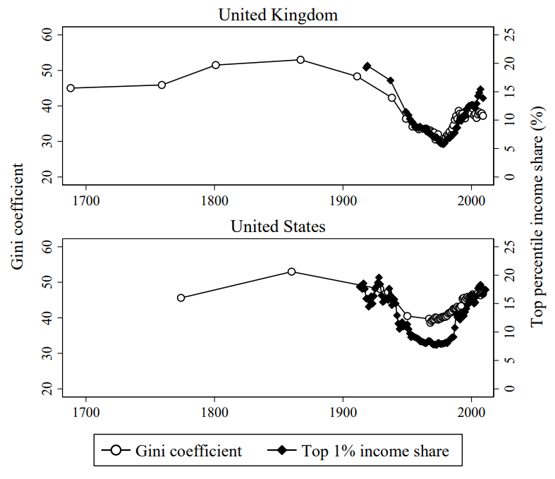

Evolución desigualdad en UK/US)

## Democratización en perspectiva (cont.)

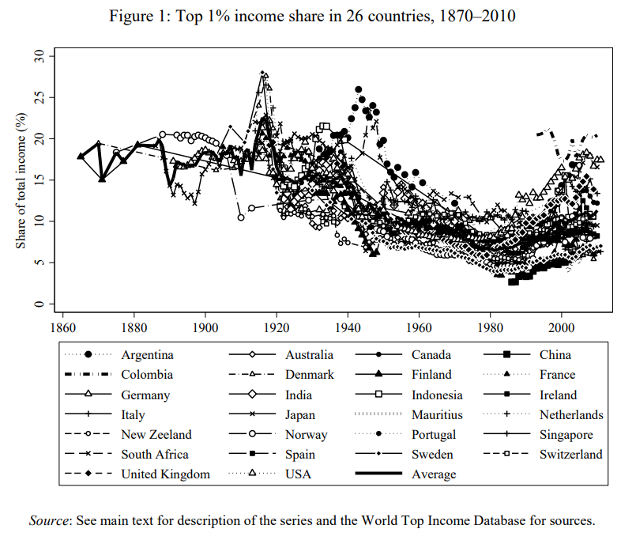

Evolución participación del top-1% en varios países)

## Democratización en perspectiva (cont.)

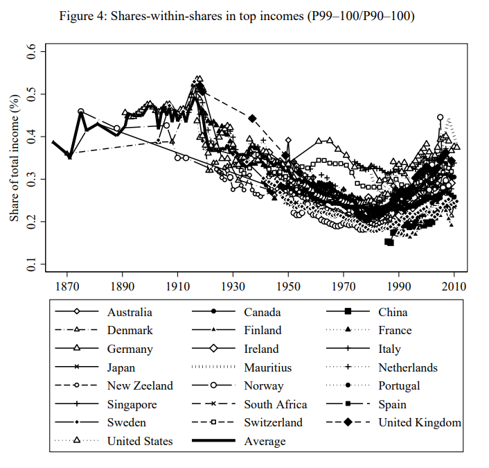

Evolución participación del ingreso total: top-1% dentro del top-10%)

## Evidencia

- Varios papers recientes ofrecen apoyo a las teorías desarrolladas
- Aidt and Leon (2016) $\longrightarrow$ democratización en Africa subsahariana entre 1990 y 2007. Profundización de huelgas y conflictos a causa de sequías provocó concesiones democráticas por parte de líderes
- Aidt and Jensen (2014) $\longrightarrow$ panel de países europeos en primera ola de democratización estudian cómo revoluciones reales en países vecinos aumentaron la probabilidad de introducir reformas en sufragio en países propios

## Evidencia (cont.)

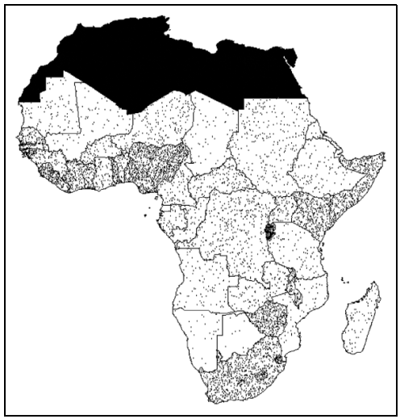

Huelgas y conflictos en Africa, 1990-2007

## Evidencia (cont.)

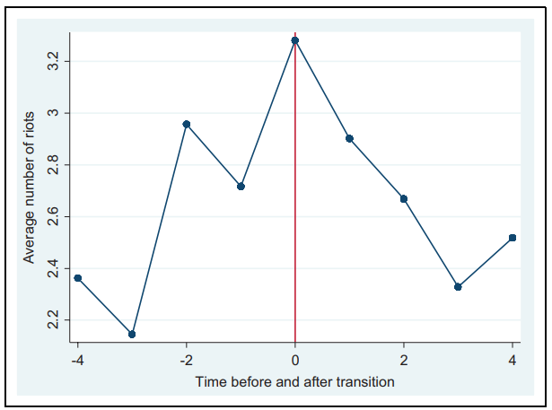

Huelgas y transiciones

## Evidencia (cont.)

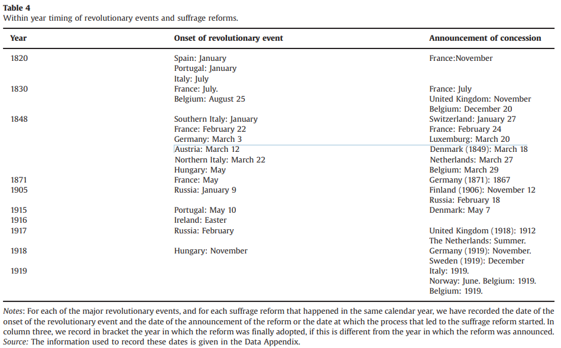

Revoluciones y concesiones: propios y vecinos

## Democracia y represión

- En los modelos anteriores y fundamentalmente en el de democracia y revolución, existen casos en que se dan revoluciones en equilibrio $\longrightarrow$ esto es en particular en el caso en que $\mu < \mu^{**}$ las revoluciones son muy poco costosas
- Hasta ahora ricos podían usar el *poder de iure* para evitar la revolución, ya sea en forma de promesas de redistribución bajo no democracia o bajo el ofrecimiento de pasar a una democracia
  - pero ricos también pueden usar el *poder de facto* para evitar revoluciones $\longrightarrow$ en forma de represión

## Democracia y represión (cont.)

- Acemoglu and Robinson (2006) reconocen que la relación entre desigualdad ($\theta$) y democratización ($D$) no es monotónica
  - A bajos niveles de $\theta$ no hay revolución [no se cumple RdR]
  - A altos niveles de $\theta$ no hay ni revolución ni democratización $\longrightarrow$ **represión**
- En otras palabras, la democratización surge en determinada “ventana” $\longrightarrow$ niveles intermedios de desigualdad
  - Supuestos: 1) represión siempre evita $R$, 2) costo de represión $\kappa$ no es excesivamente alto, 3) siempre que ricos prefieren represión a hacer concesiones, también prefieren reprimir a democratizar (costo de reprimir $\kappa$ bajo)

## Democracia y represión (cont.)

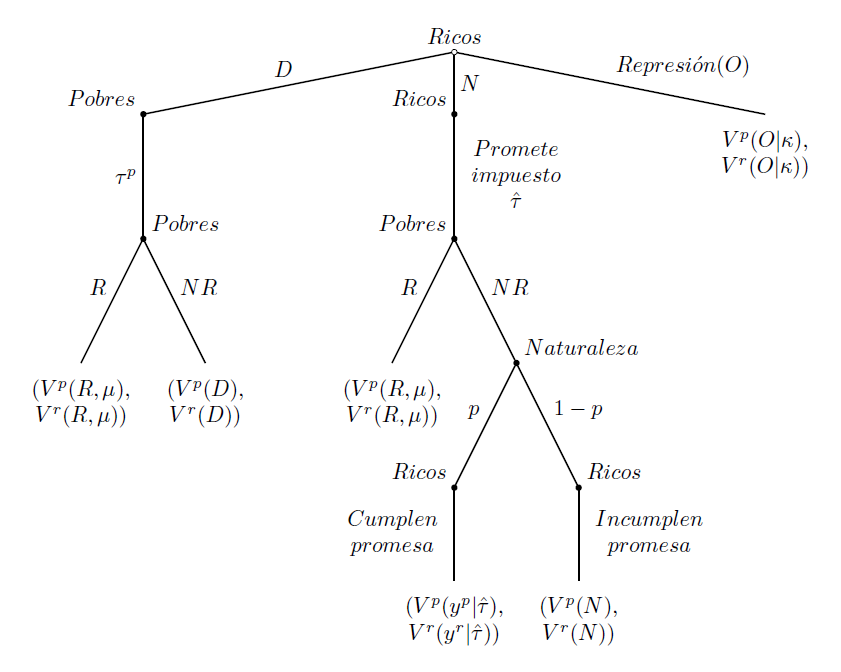

Arbol de decisiones con 3 opciones

## Democracia y represión (cont.)

- Si permitimos la represión entonces suopnemos que la represión, $O$ es una alternativa adicional a $D$ y $N$ –la represión siempre logra evitar una revolución, pero es costosa y destruye una proporción $\kappa$ del ingreso total. Pagos para pobres y ricos son:

$$\begin{align}
V^{P}(O|\kappa)=(1-\kappa)y^{P} \\
V^{R}(O|\kappa)=(1-\kappa)y^{R}
\end{align}$$

## Democracia y represión (cont.)

- Para resolver esto debemos analizar circunstancias en que **los ricos prefieren la represión**
  - a prometer redistribución y permanecer en $N$
  - a democratizar
- Se opera a partir de la restricción de revolución y se ilustran las condiciones a partir de ella

## Democracia y represión (cont.)

- Primero, hacemos

$$\begin{align}
V^{R}(O|\kappa) \geq V^{R}(N,\tau^{N}=\tilde{\tau})
\end{align}$$

- y eso nos determina:

$$\begin{align}
\kappa \leq \frac{p}{\theta}[\delta c(\tilde{\tau})-\tilde{\tau}(\delta-\theta)] \equiv \hat{\kappa}
\end{align}$$

- por lo que si $\kappa < \hat{\kappa}$ **los ricos prefieren reprimir a hacer concesiones**

## Democracia y represión (cont.)

- ¿Cuándo prefieren los ricos reprimir a democratizar?

$$\begin{align}
V^{R}(O|\kappa) \geq V^{R}(D)
\end{align}$$

- y eso nos determina:

$$\begin{align}
\kappa \leq \frac{1}{\theta}[\delta c(\tau^{P})-\tau^{P}(\delta-\theta)] \equiv \tilde{\kappa}
\end{align}$$

- por lo que si $\kappa < \tilde{\kappa}$ los **ricos prefieren reprimir a democratizar** [Note que $\hat{\kappa} < \tilde{\kappa}$]

## Democracia y represión (cont.)

- Notando que como $\hat{\kappa} < \tilde{\kappa}$, **siempre que los ricos prefieren reprimir a hacer concesiones, también prefieren reprimir a democratizar**
- Esto tiene sentido porque las concesiones se hacen a un alícuota (algo) menor a la alícuota a la que se redistribuye en democracia
  - además de que la promesa de redistribuir no siempre se cumple!

## Democracia y represión (cont.)

- Finalmente, puede demostrarse que $\frac{\partial \hat{\kappa}}{\partial \theta}>0$ y $\frac{\partial \tilde{\kappa}}{\partial \theta}>0$
  - es decir, cuando la desigualdad crece la democracia se vuelve menos atractiva (y la represión más atractiva) para los ricos! [¿por qué?]
- Pista $\longrightarrow$ demanda de redistribucion de los pobres

## Democracia y represión (cont.)

- Finalmente, puede demostrarse que $\frac{\partial \hat{\kappa}}{\partial \theta}>0$ y $\frac{\partial \tilde{\kappa}}{\partial \theta}>0$
  - es decir, cuando la desigualdad crece la democracia se vuelve menos atractiva (y la represión más atractiva) para los ricos! [¿por qué?]
- Pista $\longrightarrow$ demanda de redistribucion de los pobres

## Democracia y represión (cont.)

**Proposición 3**

Hay un equilibrio perfecto en subjuegos único para el juego representado en la figura anterior descrito por los siguientes resultados

- Si $\theta \leq \mu$:
  - la RdR no se cumple y los ricos pueden permanecer en una no-democracia sin necesidad de redistribuir ($N$), democratizar ($D$) o reprimir ($O$) [$\tau^{N}(\mu)=0$] $\longrightarrow$ los pobres eligen $NR$

## Democracia y represión (cont.)

- Este resultado sugiere que la transición hacia la democracia ocurre cuando la revolución es lo suficientemente atractiva para los pobres y cuando la represión es lo suficientemente costosa para los ricos
- La represión surge cuando es relativamente poco costosa para los ricos e incluso cuando la democracia es insuficiente para evitar un revolución (ricos van a preferir siempre primero $O$ a $R$!)

## Democracia y represión (cont.)

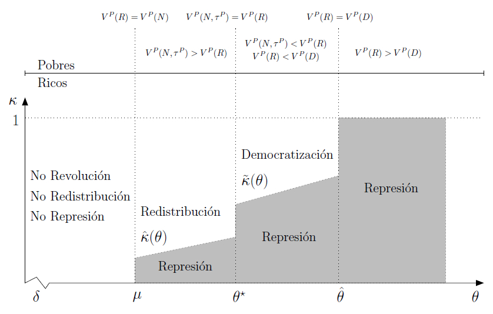

Relación entre democracia y represión

## Democracia y represión (cont.)

- Argentina rango $\theta \in (\theta^{*},\hat{\theta})$ pero mayor desigualdad que UK. Pero:
  - Democratización $\longrightarrow$ pero es costosa para la elite por alta desigualdad
  - Represión $\longrightarrow$ evita concesiones/redistribución con el costo de no democracia
    - Democracia inestable!
- Interrupciones en 1930-46, 1955-73, 1976,83

## Democracia y represión (cont.)

> **¿Qué son $\mu$ y $\kappa$ en la práctica?** Piense en lo que ponen en juego las élites. Dos tipos de élites: 1) terrateniente, 2) $K$ físico y $K$ humano. Democracia más amenazante para élites terratenientes [¿por qué?]. Revolución (y represión), por su parte, más costosa para dueños de $K$ físico y humano [¿por qué?] Ricos terratenientes más inclinados a usar represión por amenaza de revolución en contextos de alta desigualdad.

## ¿Las democracias mueren?

> It is not hard to subvert a democracy. First, subvert the electoral system. Second, capture the referees (judiciary, tax authorities, intelligence agencies & law enforcement). Third, sideline or eliminate political opponents and, above all, the media.  
> **[Levitsky and Ziblatt (2019), *How democracies die*]**